# TP2 Fouilles de données

Fabien HOS - Yasmine Darwish

2023-04-11

# 1 Importation des données

```
##        name water protein fat lactose  ash
## 1     Horse  90.1     2.6 1.0     6.9 0.35
## 2 Orangutan  88.5     1.4 3.5     6.0 0.24
## 3    Monkey  88.4     2.2 2.7     6.4 0.18
## 4    Donkey  90.3     1.7 1.4     6.2 0.40
## 5     Hippo  90.4     0.6 4.5     4.4 0.10
## 6     Camel  87.7     3.5 3.4     4.8 0.71
```

Ce jeu de données est composé de 25 lignes et de 6 colonnes. Chaque ligne représente une espèce de mammifère et la composition de son lait. Les données sont exprimées en pourcentage, nous pouvons le vérifier facilement car chaque somme de ligne correspond à 100.

# 2 Stats descriptives

Nous allons commencer par analyser nos données en regardant les statistiques de chaque variable.

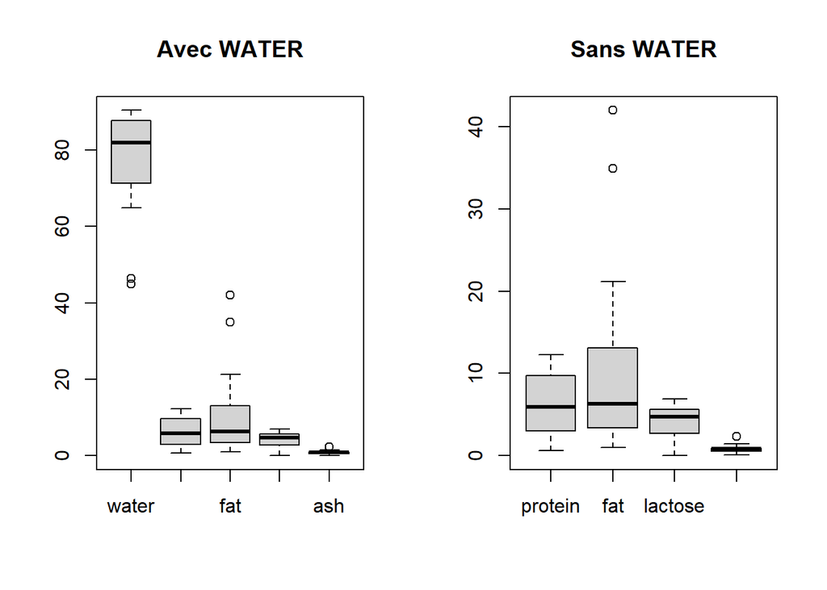

```r
par(mfrow = c(1, 2))

#Boxplot df avec eau
box1 <- boxplot(df[,-1])
title("Avec WATER")

#Boxplot df sans eau
box2 <- boxplot(df_without_water[,-1])
title("Sans WATER")
```

```r
summary(df)
```

```
##      name               water          protein            fat
##  Length:25          Min.   :44.90   Min.   : 0.600   Min.   : 1.00
##  Class :character   1st Qu.:71.30   1st Qu.: 3.000   1st Qu.: 3.40
##  Mode  :character   Median :82.00   Median : 5.900   Median : 6.30
##                     Mean   :78.18   Mean   : 6.212   Mean   :10.31
##                     3rd Qu.:87.70   3rd Qu.: 9.700   3rd Qu.:13.10
##                     Max.   :90.40   Max.   :12.300   Max.   :42.00
##     lactose           ash
##  Min.   :0.000   Min.   :0.1000
##  1st Qu.:2.700   1st Qu.:0.5300
##  Median :4.700   Median :0.8000
##  Mean   :4.132   Mean   :0.8292
##  3rd Qu.:5.600   3rd Qu.:0.9300
##  Max.   :6.900   Max.   :2.3000
```

## 2.1 Analyses de la composition du lait

### 2.1.1 Water

On remarque le lait est très majoritairement composé d’eau, peu importe l’espèce de mammifère observé, le lait est toujours composé d’au moins 44.9% d’eau et peut atteindre les 90.4%.

Pour notre analyse, nous allons constituer deux jeux de données. Nous allons conserver la variable “water” dans l’un et nous allons la retirer dans l’autre.

### 2.1.2 Fat

Le gras est la deuxième composante du lait. Ce dernier peut atteindre jusqu’à plus de 40% de la composition du lait dans le cas de certaine espèce. On remarque également que le boxplot s’étend beaucoup au dessus de la médiane, laissant penser qu’il existe des espèces avec plusieurs taux de gras dans leur lait.

### 2.1.3 Lactose

On remarque également que le lactose est une part importante de la composition, ce dernier peut être égal à 0 (chez le phoque) et atteindre 6.9%.

### 2.1.5 Ash

Les minéraux sont les éléments les moins bien représentés dans le graphique, on observe tout de même une valeur extrême chez au moins une espèce avec un pourcentage égal à 2.30%.

# 3 ACP

L’analyse en composantes principales (ACP) est une méthode statistique multivariée qui permet de réduire la dimensionnalité d’un ensemble de données en identifiant les variables les plus importantes et en les transformant en un nouveau système de coordonnées appelé “composantes principales”. Cette technique est utilisée pour explorer et visualiser la structure des données, ainsi que pour détecter des relations entre les variables et des groupes de données similaires.

Nous allons l’utiliser pour essayer de projeter dans un repère constitué de deux axes nos 5 variables composantes du lait.

## 3.1 ACP avec la variable “water”

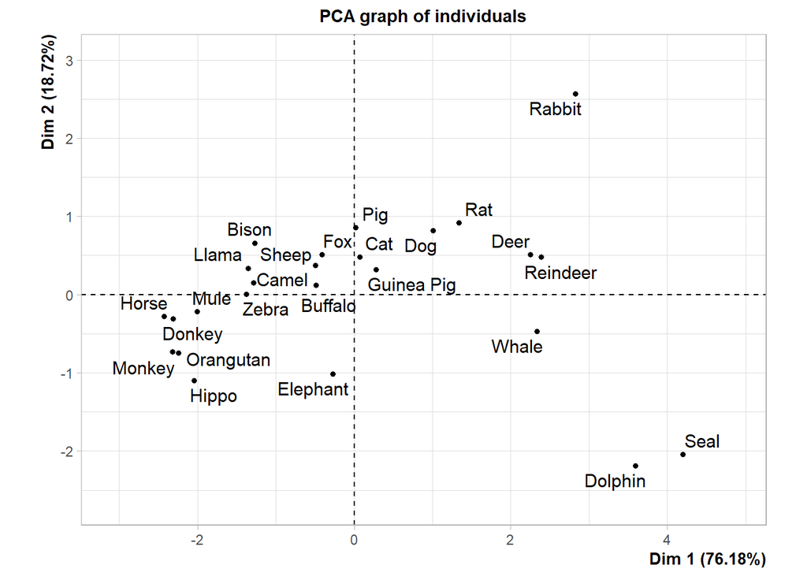

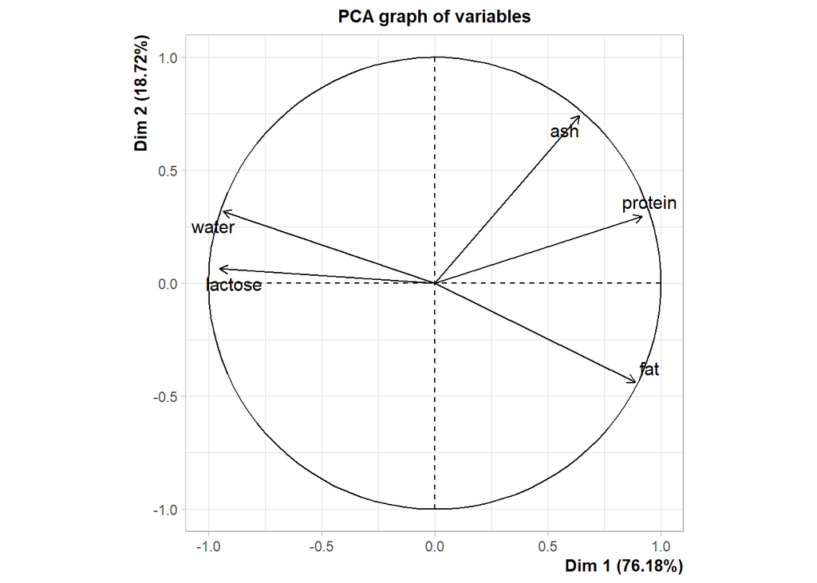

```r
library(FactoMineR) # Charger le package "factominer"

#récupérer les noms des animaux dans l'index
rownames <- df[,1]
df <- df[,-1]
rownames(df) <- rownames


# Effectuer l'ACP
resultats_acp <- PCA(df, scale.unit = T, ncp = 2, graph = TRUE)
```

```r
# Afficher les résultats
summary(resultats_acp)
```

```
##
## Call:
## PCA(X = df, scale.unit = T, ncp = 2, graph = TRUE)
##
##
## Eigenvalues
##                        Dim.1   Dim.2   Dim.3   Dim.4   Dim.5
## Variance               3.809   0.936   0.147   0.102   0.006
## % of var.             76.185  18.721   2.936   2.033   0.125
## Cumulative % of var.  76.185  94.905  97.842  99.875 100.000
##
## Individuals (the 10 first)
##                Dist    Dim.1    ctr   cos2    Dim.2    ctr   cos2
## Horse      |  2.486 | -2.427  6.185  0.953 | -0.278  0.331  0.013 |
## Orangutan  |  2.369 | -2.247  5.301  0.899 | -0.748  2.390  0.100 |
## Monkey     |  2.453 | -2.324  5.672  0.898 | -0.731  2.286  0.089 |
## Donkey     |  2.334 | -2.310  5.603  0.979 | -0.311  0.413  0.018 |
## Hippo      |  2.493 | -2.045  4.393  0.673 | -1.101  5.179  0.195 |
## Camel      |  1.342 | -1.288  1.743  0.921 |  0.148  0.094  0.012 |
## Bison      |  1.457 | -1.272  1.699  0.763 |  0.660  1.862  0.205 |
## Buffalo    |  0.520 | -0.485  0.247  0.869 |  0.121  0.063  0.054 |
## Guinea Pig |  0.963 |  0.280  0.082  0.085 |  0.317  0.430  0.109 |
## Cat        |  1.207 |  0.075  0.006  0.004 |  0.477  0.974  0.156 |
##
## Variables
##               Dim.1    ctr   cos2    Dim.2    ctr   cos2
## water      | -0.935 22.931  0.874 |  0.318 10.821  0.101 |
## protein    |  0.916 22.041  0.840 |  0.297  9.393  0.088 |
## fat        |  0.886 20.630  0.786 | -0.438 20.483  0.192 |
## lactose    | -0.949 23.664  0.901 |  0.064  0.437  0.004 |
## ash        |  0.639 10.733  0.409 |  0.742 58.866  0.551 |
```

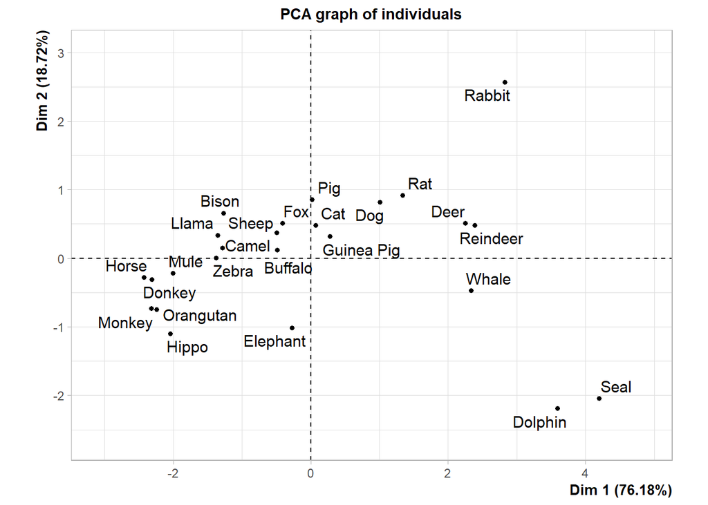

```r
plot.PCA(resultats_acp)
```

```r
resultats_acp$var$contrib
```

```
##            Dim.1      Dim.2
## water   22.93125 10.8211534
## protein 22.04115  9.3925493
## fat     20.63047 20.4830991
## lactose 23.66369  0.4369246
## ash     10.73344 58.8662736
```

En lisant les graphiques, nous pouvons voir que les variables contribuant à l’axe 1 sont les variables : water, protein, fat et lactose. Les variables protein et fat sont corrélées positivement sur l’axe 1 tandis que les variables lactosse et water sont corrélées négativement sur l’axe 1. Les variables prises 2 à 2 s’opposent.

## 3.2 Interprétation des individus sur les axes de l’ACP

Les individus à gauche du graph sont des mammifères avec un lait peu protéiné, peu gras mais avec de fortes valeurs pour le lactose et l’eau.

Remarque : *La proportion de variance expliquée par l’ACP est de 76.18% + 18.72% c’est à dire 94.9%. Nous avons donc conservé une excellente partie de l’information*

## 3.3 ACP sans la variable “water”

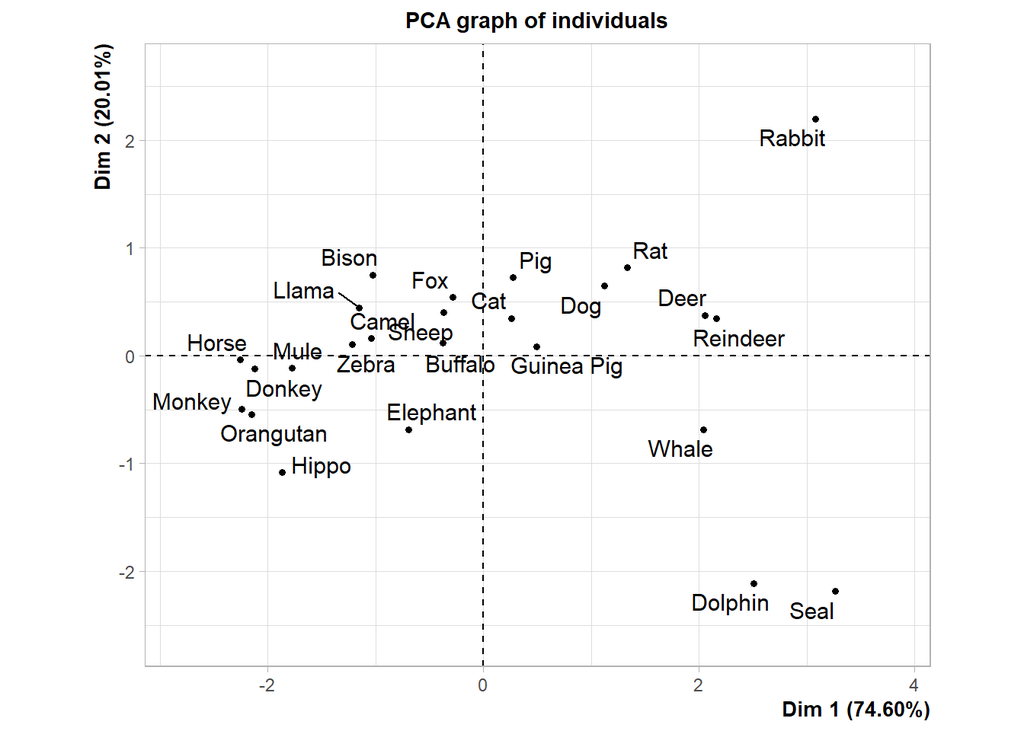

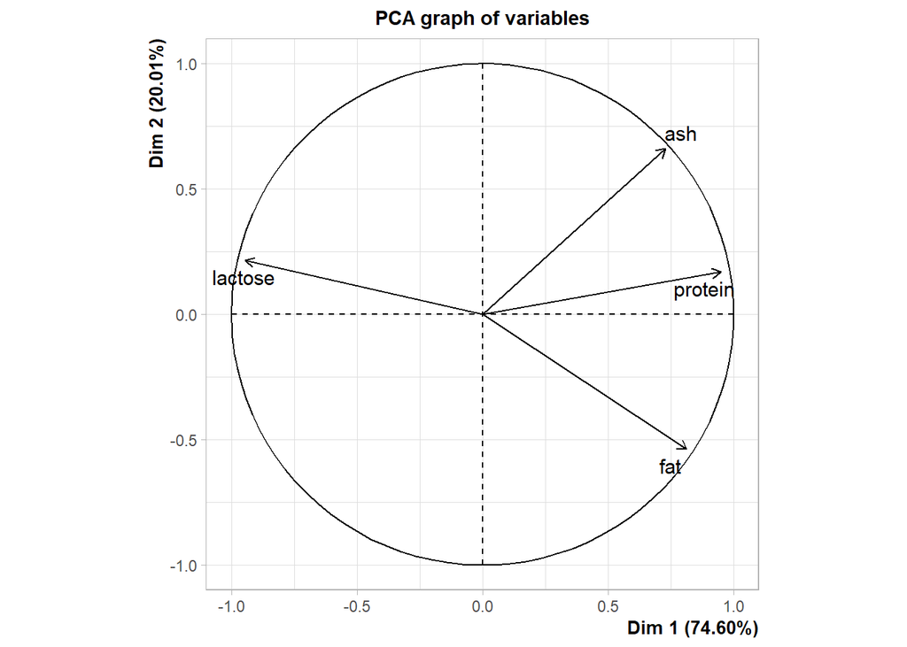

```r
#récupérer les noms des animaux dans l'index
rownames <- df_without_water[,1]
df_without_water <- df_without_water[,-1]
rownames(df_without_water) <- rownames


# Effectuer l'ACP
resultats_acp_without_water <- PCA(df_without_water, scale.unit = T, ncp = 2, graph = TRUE)
```

```r
# Afficher les résultats
summary(resultats_acp_without_water)
```

```
##
## Call:
## PCA(X = df_without_water, scale.unit = T, ncp = 2, graph = TRUE)
##
##
## Eigenvalues
##                        Dim.1   Dim.2   Dim.3   Dim.4
## Variance               2.984   0.800   0.124   0.092
## % of var.             74.596  20.011   3.098   2.294
## Cumulative % of var.  74.596  94.607  97.706 100.000
##
## Individuals (the 10 first)
##                Dist    Dim.1    ctr   cos2    Dim.2    ctr   cos2
## Horse      |  2.297 | -2.258  6.834  0.966 | -0.038  0.007  0.000 |
## Orangutan  |  2.222 | -2.154  6.218  0.939 | -0.543  1.472  0.060 |
## Monkey     |  2.314 | -2.244  6.749  0.940 | -0.496  1.229  0.046 |
## Donkey     |  2.126 | -2.119  6.020  0.994 | -0.123  0.076  0.003 |
## Hippo      |  2.295 | -1.871  4.691  0.664 | -1.080  5.827  0.221 |
## Camel      |  1.108 | -1.044  1.460  0.887 |  0.160  0.129  0.021 |
## Bison      |  1.281 | -1.023  1.404  0.639 |  0.751  2.816  0.344 |
## Buffalo    |  0.417 | -0.376  0.189  0.813 |  0.122  0.074  0.086 |
## Guinea Pig |  0.916 |  0.495  0.329  0.292 |  0.085  0.036  0.009 |
## Cat        |  1.176 |  0.260  0.091  0.049 |  0.348  0.606  0.088 |
##
## Variables
##               Dim.1    ctr   cos2    Dim.2    ctr   cos2
## protein    |  0.949 30.181  0.901 |  0.168  3.543  0.028 |
## fat        |  0.813 22.173  0.662 | -0.538 36.196  0.290 |
## lactose    | -0.944 29.882  0.892 |  0.215  5.764  0.046 |
## ash        |  0.728 17.764  0.530 |  0.660 54.497  0.436 |
```

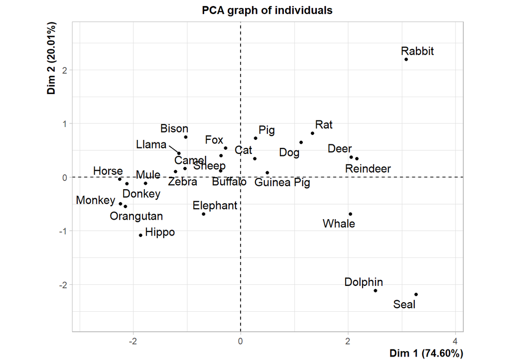

```r
plot.PCA(resultats_acp_without_water)
```

## 3.4 Interprétation de l’ACP sans la variable WATER

Nous avons perdu 2% d’informations sur l’axe 1 en retirant la variable “water” et nous avons gagné 2% sur l’axe 2. Ainsi, en retirant la variable WATER nous avons permis à la variable “ash” représentant les minéraux d’être mieux représentée. Cependant nous ne distinguons pas de différence entre les 2 ACP. Nous garderons la variable “water” pour la suite des analyses.

# 4 Classification ascendante hiérachique

La classification ascendante hiérarchique (CAH) est une méthode d’analyse de données qui permet de regrouper des individus ou des variables similaires en utilisant une approche descendante et hiérarchique. La CAH commence par considérer chaque individu ou chaque variable comme un groupe unique, puis elle combine progressivement ces groupes en fonction de leur similitude jusqu’à obtenir un arbre de classification complet.  
Cette technique est utilisée pour explorer la structure des données, détecter des groupes homogènes et déterminer des relations entre les individus ou les variables. Il est donc intéressant de l’utiliser dans le cas de données car nous cherchons à regrouper les espèces en fonction des similitudes dans leur lait.

```r
# Effectuer la CAH
arbre <- hclust(dist(resultats_acp$ind$coord), method = "ward.D2")

#Représentation des sauts de l'inertie
inertie <- sort(arbre$height, decreasing = TRUE)
```

## 4.1 Représenter les sauts d’inertie du dendrogramme

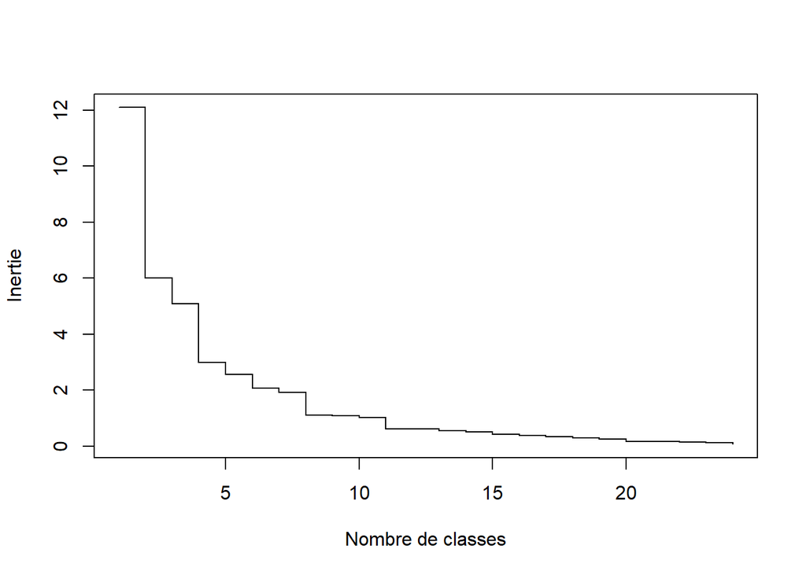

```r
plot(inertie, type = "s", xlab = "Nombre de classes", ylab = "Inertie")
```

Nous pouvons entourer les différents “sauts” d’inertie notables qui se manifestent sous la forme “grandes marches” dans le graphique.

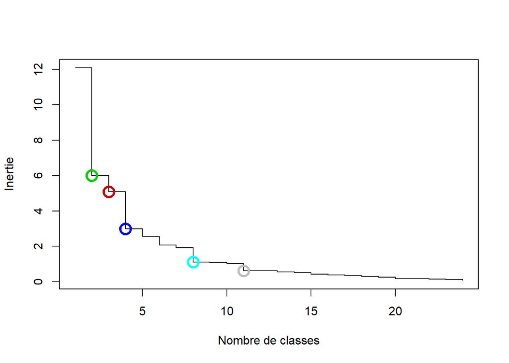

```r
plot(inertie, type = "s", xlab = "Nombre de classes", ylab = "Inertie")
points(c(2, 3, 4,8,11), inertie[c(2, 3, 4,8,11)], col = c("green3", "red3","blue","cyan","grey"), cex = 2, lwd = 3)
```

Ces sauts représentent les nombres de classes potentielles que nous pourrions utiliser pour notre classification. Le but étant de maximiser l’inertie inter-classe et minimiser l’inertie intra-classe. Autrement dit, qui se ressemble, s’assemble.

## 4.2 Découpage de l’arbre

Nous savons donc désormais que l’arbre pourrait être découpé en 2,3,4,8 ou 11 classes. Nous allons tous les représenter pour voir à quoi ressemblerait nos classes.

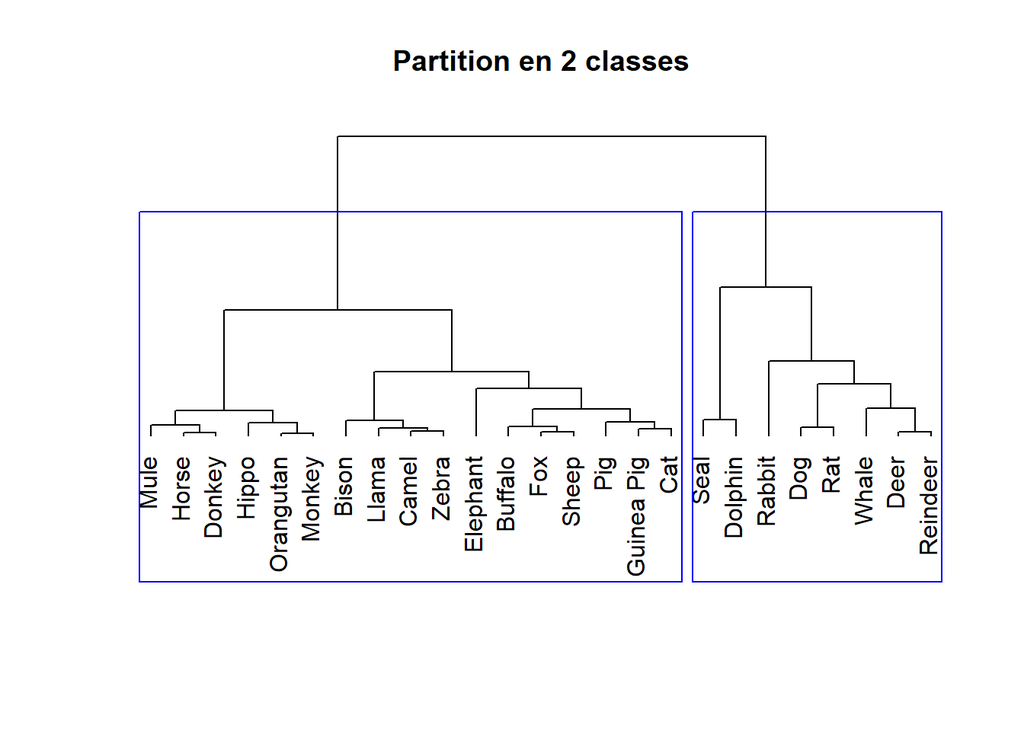

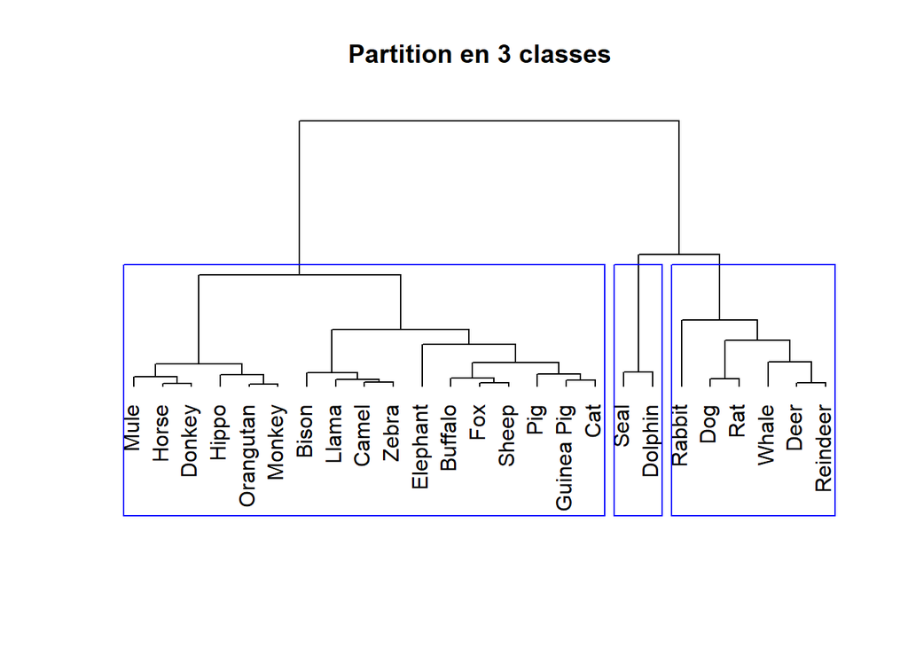

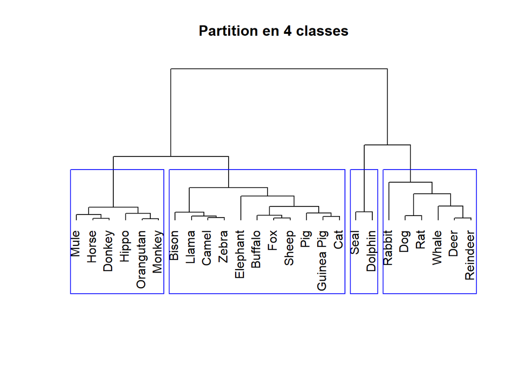

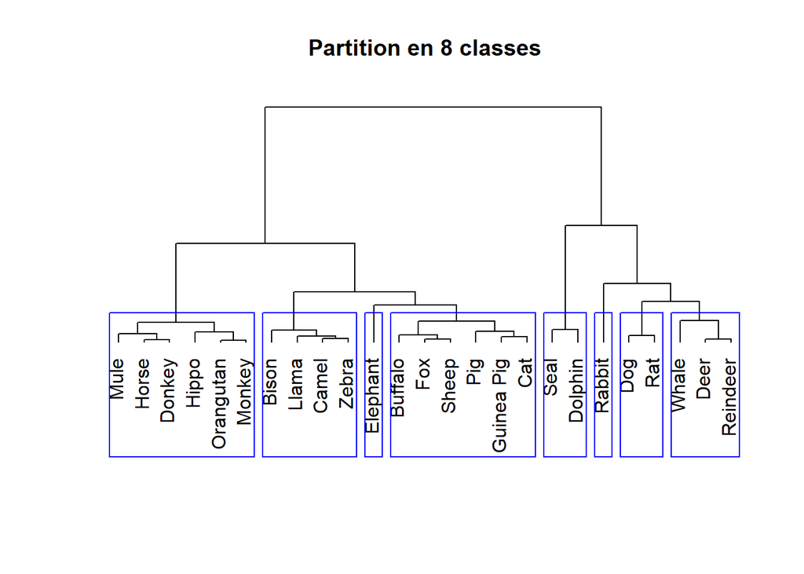

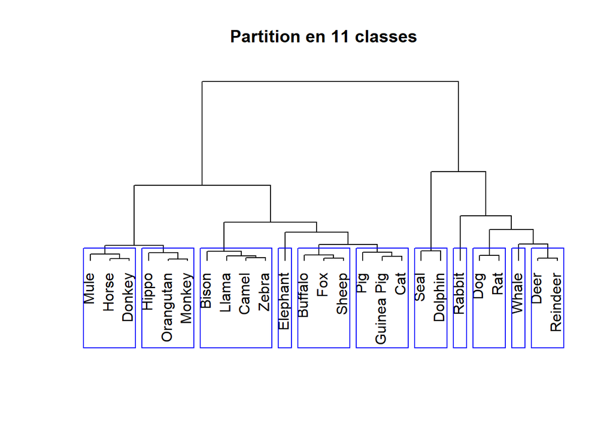

```r
classes <- c(2,3,4,8,11)

for (i in classes) {
  # Partition en i classes
  groupes.cah <- cutree(arbre, k = i)

  # Tracé du dendrogramme
  plot(arbre, main = paste("Partition en", i, "classes"),
       xlab = "", ylab = "", sub = "", axes = FALSE, hang = -1)
  rect.hclust(arbre, k = i, border = "blue")

}
```

# 5 Silhouette

La silhouette est une méthode d’évaluation de la qualité de la classification des individus dans un ensemble de données, utilisée notamment en analyse de clusters. Elle mesure à quel point chaque individu est bien classé par rapport aux autres individus de son groupe, en prenant en compte la distance entre les individus et leur centre de gravité.  
Plus la silhouette est proche de 1, plus l’individu est bien classé, tandis qu’une silhouette proche de 0 indique que l’individu pourrait être assigné à un autre groupe. La silhouette est une mesure couramment utilisée pour déterminer le nombre optimal de clusters dans un ensemble de données. Nous allons donc pouvoir quantifier la véracité de nos clusters.

```r
library(cluster)
library(factoextra)
```

```
##   cluster size ave.sil.width
## 1       1   17          0.63
## 2       2    8          0.38
```

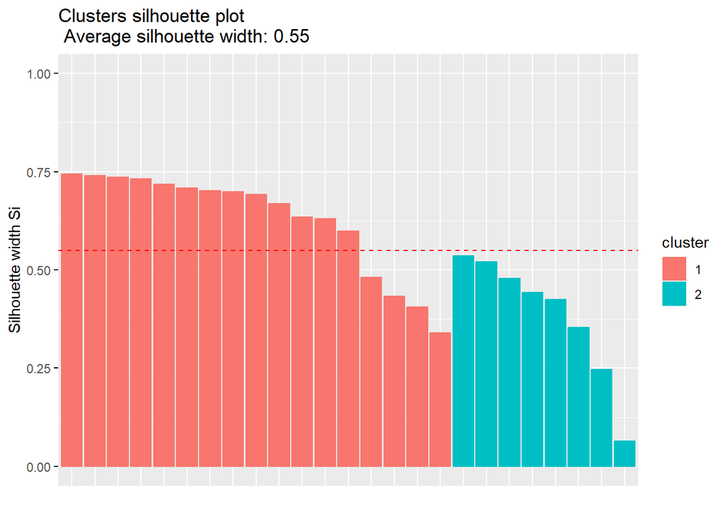

```
##   cluster size ave.sil.width
## 1       1   17          0.56
## 2       2    6          0.49
## 3       3    2          0.82
```

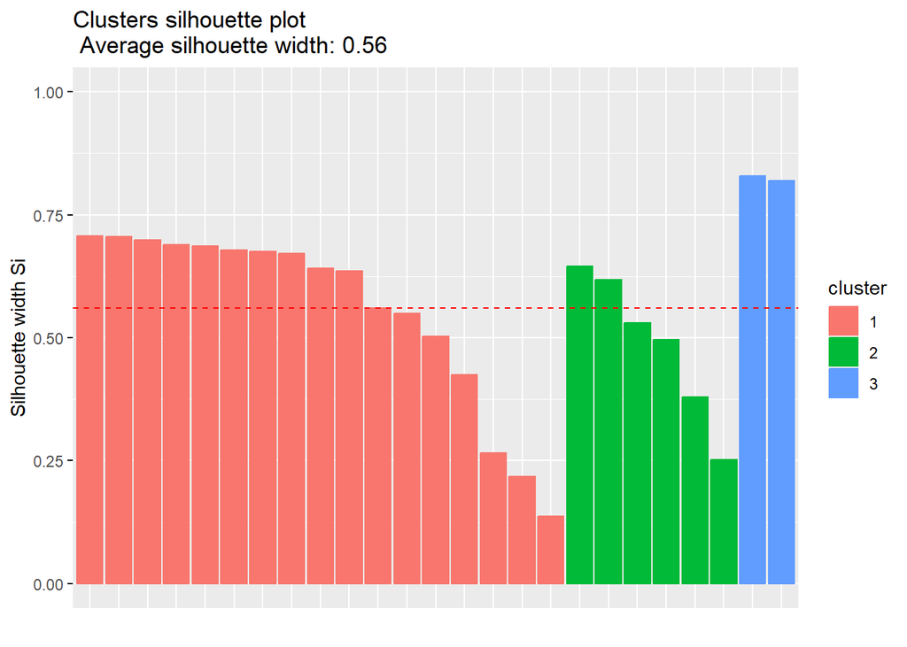

```
##   cluster size ave.sil.width
## 1       1    6          0.74
## 2       2   11          0.40
## 3       3    6          0.41
## 4       4    2          0.82
```

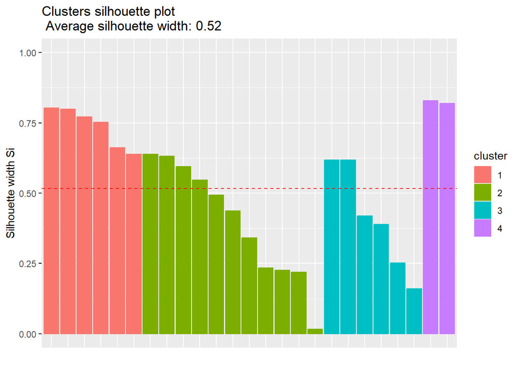

```
##   cluster size ave.sil.width
## 1       1    6          0.60
## 2       2    4          0.68
## 3       3    6          0.45
## 4       4    2          0.73
## 5       5    1          0.00
## 6       6    1          0.00
## 7       7    3          0.51
## 8       8    2          0.78
```

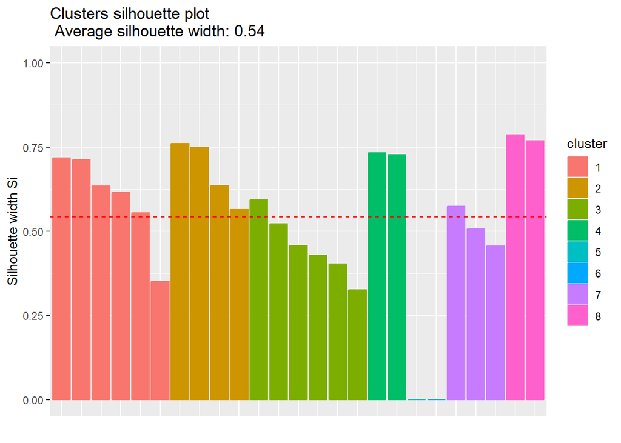

```
##    cluster size ave.sil.width
## 1        1    3          0.54
## 2        2    3          0.49
## 3        3    4          0.59
## 4        4    3          0.60
## 5        5    3          0.40
## 6        6    2          0.66
## 7        7    1          0.00
## 8        8    1          0.00
## 9        9    2          0.86
## 10      10    1          0.00
## 11      11    2          0.73
```

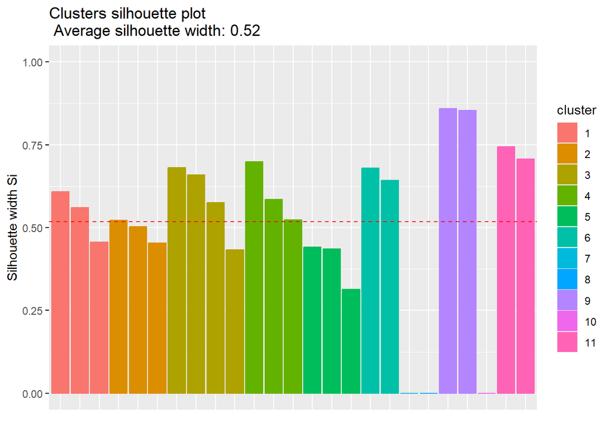

```r
# Boucle pour calculer la silhouette pour chaque nombre de classes
for (i in classes) {
  # Partition en i classes
  groupes.cah <- cutree(arbre, k = i)

  # Calcul de la silhouette
  silhouette <- silhouette(groupes.cah, dist(resultats_acp$ind$coord))

  # Affichage des résultats
  #print(paste("Silhouette pour", i, "classes :"))
  #print(silhouette)

  # Tracé de la silhouette
  print(fviz_silhouette(silhouette))
}
```

# 6 K-MEANS

K-means est une méthode de classification non supervisée largement utilisée en statistique et en apprentissage automatique. Elle est utilisée pour diviser un ensemble de données en K clusters (groupes) différents, où chaque point de données appartient à un cluster avec une similarité maximale avec les autres points du même cluster.

La méthode K-means fonctionne de la manière suivante : elle commence par choisir aléatoirement K centres de cluster (centroïdes) parmi les données. Ensuite, elle attribue chaque point de données au centroïde le plus proche. Après cela, elle calcule la moyenne de chaque cluster pour trouver le nouveau centroïde. Ce processus est répété jusqu’à ce que les centroïdes ne changent plus ou que le nombre d’itérations maximum soit atteint.

Le résultat final est une partition des données en K clusters différents, chacun caractérisé par son centroïde.

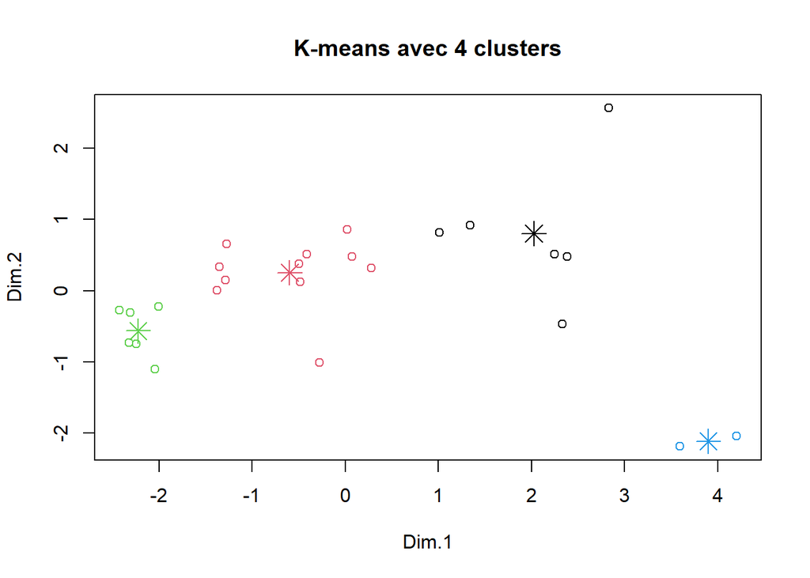

```r
nb_clusters <- 4

# Application du k-means
resultat_kmeans <- kmeans(resultats_acp$ind$coord, centers = nb_clusters)

# Visualisation des résultats du clustering
plot(resultats_acp$ind$coord, col = resultat_kmeans$cluster, main = "K-means avec 4 clusters")
points(resultat_kmeans$centers, col = 1:nb_clusters, pch = 8, cex = 2)
```

```r
resultat_kmeans$cluster
```

```
##      Horse  Orangutan     Monkey     Donkey      Hippo      Camel      Bison
##          3          3          3          3          3          2          2
##    Buffalo Guinea Pig        Cat        Fox      Llama       Mule        Pig
##          2          2          2          2          2          3          2
##      Zebra      Sheep        Dog   Elephant     Rabbit        Rat       Deer
##          2          2          1          2          1          1          1
##   Reindeer      Whale       Seal    Dolphin
##          1          1          4          4
```

## 6.1 Détermination du nombre de classes pour K-Means via la méthode du coude

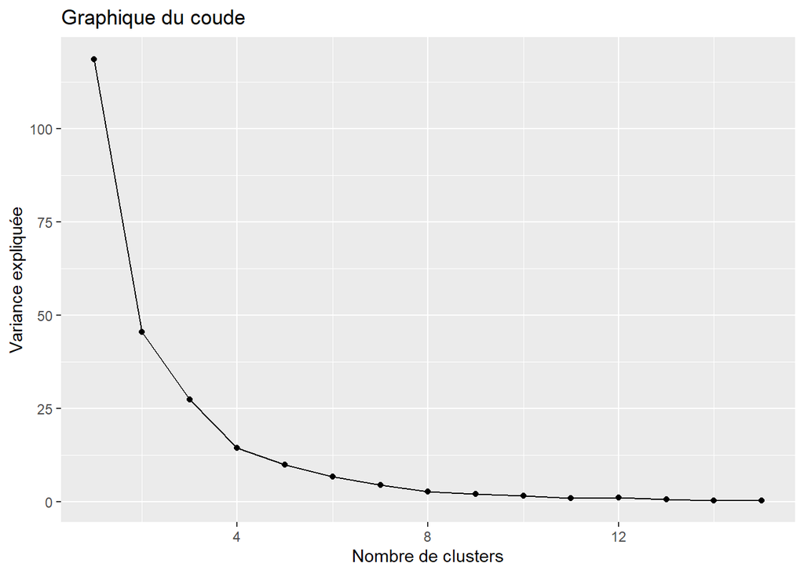

```r
# Sélection des variables à utiliser pour le clustering
vars <- c("lactose", "protein", "fat", "water", "ash")

# Calcul du graphique du coude pour les clusters de 1 à 10
set.seed(123)
kmax <- 15
sse <- numeric(kmax)
for(k in 1:kmax) {
  km.out <- kmeans(resultats_acp$ind$coord, centers = k, nstart = 25)  #acp ou dataframe ?
  sse[k] <- km.out$tot.withinss
}

# Affichage du graphique du coude
ggplot(data.frame(k = 1:kmax, SSE = sse), aes(x = k, y = SSE)) +
  geom_point() +
  geom_line() +
  labs(title = "Graphique du coude", x = "Nombre de clusters", y = "Variance expliquée")
```

## 6.2 Statistiques descriptives des classes obtenues via la K-means

```r
# Comptage du nombre d'observations dans chaque classe
table(resultat_kmeans$cluster)
```

```
##
##  1  2  3  4
##  6 11  6  2
```

[figure not shown]

[figure not shown]

[figure not shown]

[figure not shown]

[figure not shown]

```r
# Sélection des variables à utiliser pour le clustering
variables <- c("fat", "water", "lactose","ash","protein")

# Graphique des histogrammes pour chaque variable en distinguant les classes par des couleurs différentes
par(mfrow=c(4,1))
for (i in 1:length(variables)) {
  hist(df[, variables[i]][resultat_kmeans$cluster == 1], main=paste("Cluster 1 - ", variables[i]), col="blue")
  hist(df[, variables[i]][resultat_kmeans$cluster == 2], main=paste("Cluster 2 - ", variables[i]), col="green")
  hist(df[, variables[i]][resultat_kmeans$cluster == 3], main=paste("Cluster 3 - ", variables[i]), col="red")
  hist(df[, variables[i]][resultat_kmeans$cluster == 4], main=paste("Cluster 4 - ", variables[i]), col="orange")
}
```

```r
# Statistiques descriptives pour chaque classe
for (i in 1:max(resultat_kmeans$cluster)) {
  print(paste("Cluster", i))
  print(summary(df[resultat_kmeans$cluster == i, variables]))
}
```

```
## [1] "Cluster 1"
##       fat            water          lactose           ash
##  Min.   : 9.50   Min.   :64.80   Min.   :1.600   Min.   :0.850
##  1st Qu.:12.72   1st Qu.:65.08   1st Qu.:2.050   1st Qu.:1.250
##  Median :16.40   Median :68.60   Median :2.550   Median :1.400
##  Mean   :16.07   Mean   :69.27   Mean   :2.483   Mean   :1.425
##  3rd Qu.:20.15   3rd Qu.:72.20   3rd Qu.:2.900   3rd Qu.:1.400
##  Max.   :21.20   Max.   :76.30   Max.   :3.300   Max.   :2.300
##     protein
##  Min.   : 9.200
##  1st Qu.: 9.575
##  Median :10.550
##  Mean   :10.500
##  3rd Qu.:11.000
##  Max.   :12.300
## [1] "Cluster 2"
##       fat             water          lactose           ash
##  Min.   : 1.700   Min.   :70.70   Min.   :2.700   Min.   :0.6300
##  1st Qu.: 4.100   1st Qu.:81.75   1st Qu.:4.550   1st Qu.:0.7300
##  Median : 5.900   Median :82.10   Median :4.800   Median :0.8000
##  Mean   : 6.318   Mean   :82.73   Mean   :4.736   Mean   :0.8236
##  3rd Qu.: 6.800   3rd Qu.:86.35   3rd Qu.:5.450   3rd Qu.:0.9050
##  Max.   :17.600   Max.   :87.70   Max.   :5.700   Max.   :1.1000
##     protein
##  Min.   : 3.000
##  1st Qu.: 3.750
##  Median : 5.600
##  Mean   : 5.591
##  3rd Qu.: 6.850
##  Max.   :10.100
## [1] "Cluster 3"
##       fat            water          lactose           ash
##  Min.   :1.000   Min.   :88.40   Min.   :4.400   Min.   :0.1000
##  1st Qu.:1.500   1st Qu.:88.88   1st Qu.:5.625   1st Qu.:0.1950
##  Median :2.250   Median :90.05   Median :6.100   Median :0.2950
##  Mean   :2.483   Mean   :89.62   Mean   :5.900   Mean   :0.2900
##  3rd Qu.:3.300   3rd Qu.:90.25   3rd Qu.:6.350   3rd Qu.:0.3875
##  Max.   :4.500   Max.   :90.40   Max.   :6.900   Max.   :0.4700
##     protein
##  Min.   :0.600
##  1st Qu.:1.475
##  Median :1.850
##  Mean   :1.750
##  3rd Qu.:2.150
##  Max.   :2.600
## [1] "Cluster 4"
##       fat            water          lactose           ash
##  Min.   :34.90   Min.   :44.90   Min.   :0.000   Min.   :0.53
##  1st Qu.:36.67   1st Qu.:45.27   1st Qu.:0.225   1st Qu.:0.61
##  Median :38.45   Median :45.65   Median :0.450   Median :0.69
##  Mean   :38.45   Mean   :45.65   Mean   :0.450   Mean   :0.69
##  3rd Qu.:40.23   3rd Qu.:46.02   3rd Qu.:0.675   3rd Qu.:0.77
##  Max.   :42.00   Max.   :46.40   Max.   :0.900   Max.   :0.85
##     protein
##  Min.   : 9.700
##  1st Qu.: 9.925
##  Median :10.150
##  Mean   :10.150
##  3rd Qu.:10.375
##  Max.   :10.600
```

```r
# Test d'ANOVA pour comparer les moyennes des variables entre les différentes classes
#for (i in 1:length(variables)) {
 # print(paste("Variable", variables[i]))
  #print(summary(aov(df[, variables[i]] ~ resultat_kmeans$cluster)))
#}
```

# 7 Rphylopic

Nous avons consulté la documentation, il semblerait que pour utiliser le package, nous ayons besoin du nom scientifique de l’animal, ce qui n’est pas notre cas dans notre jeu de données. De plus, il ne semble pas possible d’intégrer plusieurs “phylopic” dans un graphique (celui de la classification kmeans).

# 8 Seriation

Le package R “seriation” est une collection de fonctions qui permettent de réaliser des analyses de sériation. La sériation est une méthode d’analyse de données qui consiste à ordonner des objets selon leur similarité, afin de révéler des structures et des tendances dans les données.

```r
library(seriation)
```

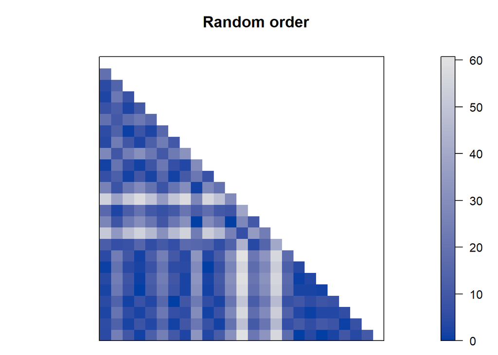

```r
df_2 <- all.mammals.milk.1956
df_2 <- df_2[,-1]

# Réorganiser les objets au hasard
set.seed(123)
df_2 <- df_2[sample(seq_len(nrow(df_2))),]

# Calculer la matrice de dissimilarité
dist_result <- dist(df_2)

# Sérier les objets, réorganiser les lignes en fonction de leur similarité
object_order <- seriate(dist_result)

# Visualiser l'effet de la sériation sur la matrice de dissimilarité
pimage(dist_result, main = "Random order")
```

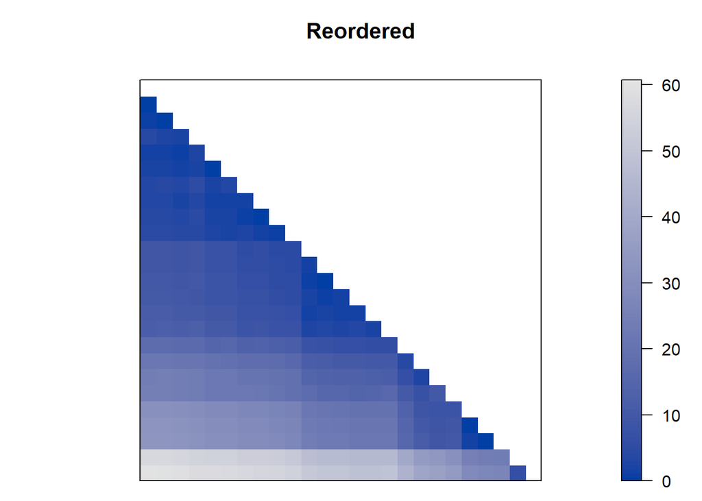

```r
pimage(dist_result, order = object_order, main = "Reordered")
```

## 8.1 Visualisation sous la forme d’heatmap

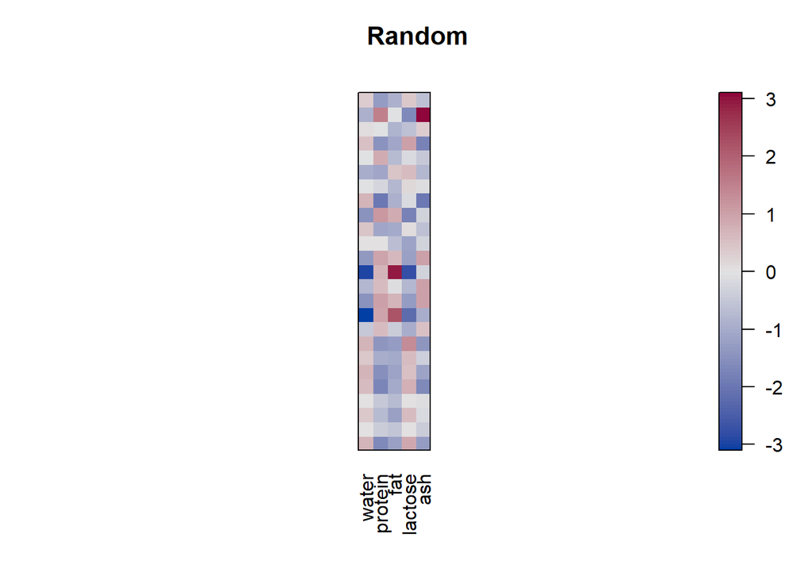

```r
# Heatmap des données brutes
pimage(scale(df_2), main = "Random")
```

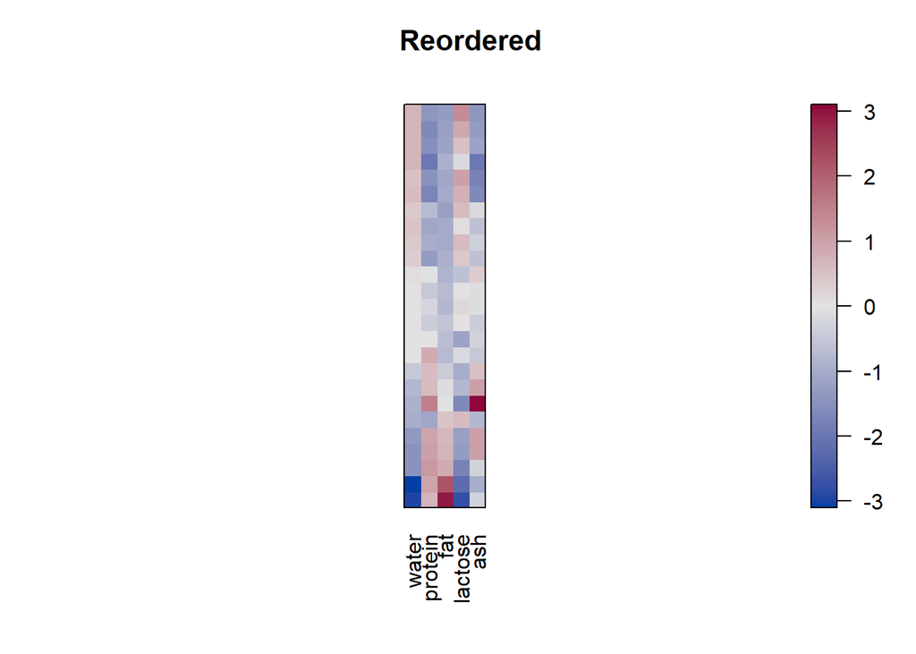

```r
# Heatmap des données réorganisées
pimage(scale(df_2), order = c(object_order, NA), main = "Reordered")
```

En regardant la heatmap “Reordered” nous voyons que chaque observation a été classé en fonction des des valeurs pour chaque variable. On retrouve les mêmes observations que dans l’ACP, c’est à dire que les espèces avec de fortes valeurs pour le lactose et l’eau possèdent de faibles valeurs pour les minéraux, le gras et les protéines et réciproquement.